# MiniProject4

## Mini-Project 4: Solving n-queens Problem using Evolutionary Computation

#### CSC 180 Intelligent Systems (Fall 2019)

#### Dr. Haiquan Chen, California State University, Sacramento

```python
# Insert your name, your id, course title, assignment id, and due date here as comment


# Ronngguang Ou (219817313)
# John Leonardo (216649967)
# Manuel Herrera (219721880)
# CSC 180 Intelligent Systems
# Mini-Project 4
# November 15, 2019
```

## Part I: Position-index-based board representation

```python
import random
import numpy as np
from deap import algorithms, base, creator, tools

creator.create("FitnessMin", base.Fitness, weights=(-1.0,))
creator.create("Individual", list, fitness=creator.FitnessMin)
```

```python
def create_individual():
    return random.sample(range(64), 8)
```

```python
print(create_individual())
```

```
[16, 19, 8, 23, 29, 1, 54, 52]
```

```python
def show_grid(board):

    n = [0]*64
    for i in board:
        n[i] = 1


    for i in range(8):
        for j in range(64):
            if j // 8 == i:
                if n[j] == 1:
                    print('X',end="|")
                else:
                    print('-',end="|")
        print()
        print("----------------")
```

```python
toolbox = base.Toolbox()

toolbox.register("individual", tools.initIterate, creator.Individual, create_individual)

toolbox.register("population", tools.initRepeat, list, toolbox.individual)
```

```python
pop = toolbox.population(n=5)

print(pop[0])
```

```
[10, 48, 3, 51, 59, 53, 32, 36]
```

```python
show_grid(pop[0])
```

```
-|-|-|X|-|-|-|-|
----------------
-|-|X|-|-|-|-|-|
----------------
-|-|-|-|-|-|-|-|
----------------
-|-|-|-|-|-|-|-|
----------------
X|-|-|-|X|-|-|-|
----------------
-|-|-|-|-|-|-|-|
----------------
X|-|-|X|-|X|-|-|
----------------
-|-|-|X|-|-|-|-|
----------------
```

### 10 pts: Write your code in the cell below to define the "evaFitness" function, which return the fitness of any given board.

- Noticed that in this case, mutation may generate invalid board, e.g., the board with dupliciate positions. Think about [5, 32, 8, 8, 41, 3, 55, 49]
- How to exclude those invalid boards from each generation? One way is to add some penalty to the fitness value of invalid boards. In that case, any invalid board will have a very high fitness value (remember that our goal is to find the board with least fitness value). To do that, let's write a function *checkDuplicate()* to calculate the number of queen pairs in the same position for any given board and add that function to the fitness value.
- evaFitness() returns the total number of duplicate position pair plus the total number of distinct pairs of queens that attack each other.

```python
import math
#fitness function
def evaFitness(individual):
    individual.sort()
    conflict = 0

    x = [0]*8 #Stores x coordinate of individual[i]
    y = [0]*8 #Store y coordinate of individual[i]

    for i in range(8):
        x[i] = individual[i] % 8 #Compute x coordinate
        y[i] = individual[i]//8 #Compute y coordinate

    #Count Column,Row conflicts
    for i in range(8):
        nodeY = 0
        nodeX = 0
        for j in range(8):
            if x[j] == i:
                nodeY += 1
            if y[j] == i:
                nodeX += 1
        if nodeY > 1:
            conflict += math.factorial(nodeY)/math.factorial(nodeY-2)/2
        if nodeX > 1:
            conflict += math.factorial(nodeX)/math.factorial(nodeX-2)/2

    #Count diagonal conflicts
    for i in range(7):
        for j in range(i+1,8):
            if(abs(x[i]-x[j]) == abs(y[i]-y[j])):
                conflict += 1

    return (checkDuplicate(individual) + conflict,)


# Calculate the number of queen pairs in the same position for any given board
def checkDuplicate(individual):
    mapping= {}
    dup = 0
    for i in individual:
        if i not in mapping:
            mapping[i] = 1
        else:
            mapping[i] = mapping[i] + 1
            if mapping[i] == 2:
                dup = dup + 1
                mapping[i] = 0
    if dup > 0:
        return 10000 #Invalid individual are given high penalty so it gets filtered
    else:
        return dup
```

### 5 pts: Writer your code in the cell below to register "evaluate" function to toolbox

```python
print(pop[0])
show_grid(pop[0])
```

```
[0, 3, 15, 20, 25, 35, 46, 58]
X|-|-|X|-|-|-|-|
----------------
-|-|-|-|-|-|-|X|
----------------
-|-|-|-|X|-|-|-|
----------------
-|X|-|-|-|-|-|-|
----------------
-|-|-|X|-|-|-|-|
----------------
-|-|-|-|-|-|X|-|
----------------
-|-|-|-|-|-|-|-|
----------------
-|-|X|-|-|-|-|-|
----------------
```

```python
evaFitness(pop[0])
```

```
(2.0,)
```

```python
toolbox.register("evaluate", evaFitness)

toolbox.register("mate", tools.cxTwoPoint)

toolbox.register("mutate", tools.mutUniformInt, low = 0, up = 63, indpb=0.1)

toolbox.register("select", tools.selTournament, tournsize=3)
```

```python
stats = tools.Statistics(key=lambda ind: ind.fitness.values)
```

```python
stats.register("avg", np.mean)
stats.register("min", np.min)
```

### 10 pts: Writer your code in the cell below to create the first generation, the hall of fame, and launch the genetic algorithm: eaSimple(). Run the algorithm for 100 generations.

```python
#Create generation 0 , composed of 50 individuals
pop = toolbox.population(n=50)
#Create HallofFame varible to store best individual
hof = tools.HallOfFame(maxsize=1)
#Run eaSimple for 100 generation
pop, log = algorithms.eaSimple(pop, toolbox, cxpb=0.2, mutpb=0.3, ngen=100,
                                   stats=stats, halloffame=hof, verbose=True)
```

```
gen	nevals	avg 	min
0  	50    	9.98	5
1  	25    	208.12	5
2  	22    	807.28	5
3  	22    	606.6 	5
4  	20    	406.36	4
5  	18    	1005.98	4
6  	24    	5.56   	4
7  	23    	805.22 	4
8  	17    	404.78 	4
9  	22    	404.6  	3
10 	23    	4.22   	3
11 	18    	3.92   	3
12 	22    	804.06 	3
13 	23    	203.4  	3
```

[output cut: 87 more lines]

### 5 pts: Plot the "avg" and "min" for each generation

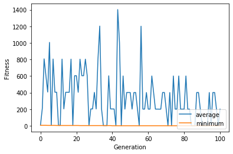

```python
import matplotlib.pyplot as plt
%matplotlib inline

gen, avg, min_ = log.select("gen", "avg", "min")

plt.plot(gen, avg, label="average")
plt.plot(gen, min_, label="minimum")
plt.xlabel("Generation")
plt.ylabel("Fitness")
plt.legend(loc="lower right")
plt.show()
```

### 5 pts: Print out the best individual found and its fitness value. Show the best individual as chessboard

```python
print("Best individual is: ", hof[0] , " with fitness: " , hof[0].fitness)
show_grid(hof[0])
```

```
Best individual is:  [2, 12, 17, 31, 37, 43, 54, 56]  with fitness:  (0.0,)
-|-|X|-|-|-|-|-|
----------------
-|-|-|-|X|-|-|-|
----------------
-|X|-|-|-|-|-|-|
----------------
-|-|-|-|-|-|-|X|
----------------
-|-|-|-|-|X|-|-|
----------------
-|-|-|X|-|-|-|-|
----------------
-|-|-|-|-|-|X|-|
----------------
X|-|-|-|-|-|-|-|
----------------
```

## Part II: Row-index-based board representation

```python
import random
import numpy as np
from deap import algorithms, base, creator, tools

creator.create("FitnessMin", base.Fitness, weights=(-1.0,))
creator.create("Individual", list, fitness=creator.FitnessMin)
```

Each row of the chess row is indexed from 0->7 . we place different queens on different rows initially. The sequence [ a b c d .... ] means that in $0^{th}$ row, $a^{th}$ column, the queen is present and so on

```python
toolbox = base.Toolbox()

toolbox.register("attr_int", random.randint, 0, 7)
toolbox.register("individual", tools.initRepeat, creator.Individual,
                 toolbox.attr_int, n=8)
```

```python
toolbox.individual()
```

```
[0, 5, 5, 3, 2, 6, 5, 4]
```

```python
def show_grid(board):

    n = [0]*64

    for i in range(len(board)):
        n[board[i] + i*8] = 1


    for i in range(8):
        for j in range(64):
            if j // 8 == i:
                if n[j] == 1:
                    print('X',end="|")
                else:
                    print('-',end="|")
        print()
        print("----------------")
```

```python
toolbox.register("population", tools.initRepeat, list, toolbox.individual)
```

```python
pop = toolbox.population(n=5)

print(pop[0])
```

```
[3, 4, 2, 2, 5, 0, 3, 6]
```

```python
show_grid([0, 2, 6, 7, 7, 6, 5, 6])
```

```
X|-|-|-|-|-|-|-|
----------------
-|-|X|-|-|-|-|-|
----------------
-|-|-|-|-|-|X|-|
----------------
-|-|-|-|-|-|-|X|
----------------
-|-|-|-|-|-|-|X|
----------------
-|-|-|-|-|-|X|-|
----------------
-|-|-|-|-|X|-|-|
----------------
-|-|-|-|-|-|X|-|
----------------
```

### 10 pts: Write your code in the cell below to define the "evaFitness" function, which return the fitness of any given board

- evaFitness() returns the total number of distinct pairs of queens that attack each other.
- The following are some test cases you may use to verify the correctness of the evaFitness() function:
  - evaFitness([0, 2, 6, 7, 7, 4, 1, 6]) should return (4,)
  - evaFitness([7, 5, 2, 4, 3, 1, 3, 5]) should return (6,)
  - evaFitness([3, 1, 6, 0, 5, 7, 2, 1]) should return (5,)
  - evaFitness([7, 3, 1, 4, 5, 1, 3, 5]) should return (6,)

```python
#fitness function
def evaFitness2(individual):
    #Convert to position based representation
    v1 = [0]*8
    for i in range(8):
        v1[i] = 8*i + individual[i]
    return evaFitness(v1)
```

```python
evaFitness2([7,5,2,4,3,1,3,5])
```

```
(6.0,)
```

### 5 pts: Writer your code in the cell below to register "evaluate" function to toolbox

```python
toolbox.register("evaluate" , evaFitness2)
```

```python
toolbox.register("mate", tools.cxTwoPoint)

toolbox.register("mutate", tools.mutUniformInt, low = 0, up = 7, indpb=0.1)

toolbox.register("select", tools.selTournament, tournsize=3)
```

```python
stats = tools.Statistics(key=lambda ind: ind.fitness.values)

stats.register("avg", np.mean)
stats.register("min", np.min)
```

### 10 pts: Writer your code in the cell below to create the first generation, the hall of fame, and launch the genetic algorithm: eaSimple(). Run the algorithm for 100 generations.

```python
#Create population composed of 50 individuals as Generation 0
pop = toolbox.population(n=50)

#Create HallOfFame variable to store best individual
hof = tools.HallOfFame(maxsize=1)

#Run eaSimple for 100 generation
pop, log = algorithms.eaSimple(pop, toolbox, cxpb=0.5, mutpb=0.3, ngen=100,
                                   stats=stats, halloffame=hof, verbose=True)
```

```
gen	nevals	avg 	min
0  	50    	7.68	3
1  	29    	6.24	3
2  	36    	5.72	3
3  	34    	5.3 	3
4  	34    	5.24	3
5  	38    	4.02	2
6  	37    	3.84	2
7  	33    	3.64	2
8  	28    	3.24	2
9  	34    	3.12	0
10 	32    	2.7 	0
11 	38    	2.32	0
12 	32    	2.14	0
13 	34    	1.84	0
```

[output cut: 87 more lines]

### 5 pts: Plot the "avg" and "min" for each generation

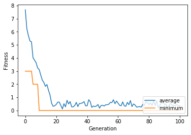

```python
# Plot the "avg" and "min" for each generation

import matplotlib.pyplot as plt
%matplotlib inline

gen, avg, min_ = log.select("gen", "avg", "min")

plt.plot(gen, avg, label="average")
plt.plot(gen, min_, label="minimum")
plt.xlabel("Generation")
plt.ylabel("Fitness")
plt.legend(loc="lower right")
plt.show()
```

### 5 pts: Print out the best individual found and its fitness value. Show the best individual as chessboard

```python
print("Best individual is: ", hof[0] , " with fitness: " , hof[0].fitness)
show_grid(hof[0])
```

```
Best individual is:  [1, 3, 5, 7, 2, 0, 6, 4]  with fitness:  (0.0,)
-|X|-|-|-|-|-|-|
----------------
-|-|-|X|-|-|-|-|
----------------
-|-|-|-|-|X|-|-|
----------------
-|-|-|-|-|-|-|X|
----------------
-|-|X|-|-|-|-|-|
----------------
X|-|-|-|-|-|-|-|
----------------
-|-|-|-|-|-|X|-|
----------------
-|-|-|-|X|-|-|-|
----------------
```

### Reflection: Which board representaion is better? Try different parameter values for mutation and crossover or vary the number of generations you want to go through, and write your findings in the report.